# Question 2 Analysis

Siva Lakshmi

2026-04-25

```r
library(tidyverse)

raw_files <- c(
  "2019" = "../../data/raw/PSI_IPC_2019.csv",
  "2020" = "../../data/raw/PSI_IPC_2020.csv",
  "2021" = "../../data/raw/PSI_IPC_2021.csv",
  "2022" = "../../data/raw/PSI_IPC_2022.csv",
  "2023" = "../../data/raw/PSI_IPC_2023.csv"
)

process_file <- function(year, path) {
  df <- read.csv(path, check.names = FALSE, stringsAsFactors = FALSE)

  clean_df <- data.frame(
    Year = as.numeric(year),
    State = toupper(trimws(as.character(df[[2]]))), # Col 2: State
    Murder = suppressWarnings(as.numeric(df[[3]])), # Col 3: Murder
    `Attempt to commit Murder` = suppressWarnings(as.numeric(df[[6]])), # Col 6: Attempt
    `Kidnapping & Abduction` = suppressWarnings(as.numeric(df[[7]])), # Col 7: Kidnapping
    Theft = suppressWarnings(as.numeric(df[[12]])), # Col 12: Theft
    Robbery = suppressWarnings(as.numeric(df[[14]])), # Col 14: Robbery
    Burglary = suppressWarnings(as.numeric(df[[20]])), # Col 20: Burglary
    check.names = FALSE
  )

  clean_df <- clean_df %>%
    filter(!grepl("TOTAL|INDIA", State, ignore.case = TRUE)) %>%
    replace(is.na(.), 0)

  return(clean_df)
}

crime_data <- map2_dfr(names(raw_files), raw_files, process_file)
```

# Comprehensive Report: State Crime Profiles and Conviction Patterns (2019–2023)

## 1. Parent Question

**Do states exhibit distinct “crime profiles” based on the composition of convictions?**

## Sub-Question 2.1: Classifying Prison Populations (Violence vs. Property)

**Using a simple ratio metric, can we classify states on a spectrum from “Violence-Dominant” to “Property-Dominant” prisons? How has Uttar Pradesh’s position on this spectrum shifted from 2019 to 2023 compared to Tamil Nadu?**

### Statistical Methods Used

- Composite Index Calculation
- Comparative Time Series Plot Visualization

### Step-by-Step Application

1. **Defining Ratio:** Created a `Violence_Index` calculated as the sum of violent crimes (Murder, Attempt to Murder, Kidnapping) divided by property crimes (Theft, Burglary, Robbery).
2. **Yearly Calculation:** Computed this index for every state across the 5-year period (2019–2023).
3. **National Benchmarking:** Calculated the national average for the index across the same period.
4. **Visualization:** Plotted a time series line chart isolating Uttar Pradesh (UP), Tamil Nadu (TN), and the National Average to observe relative shifts.

### R Code

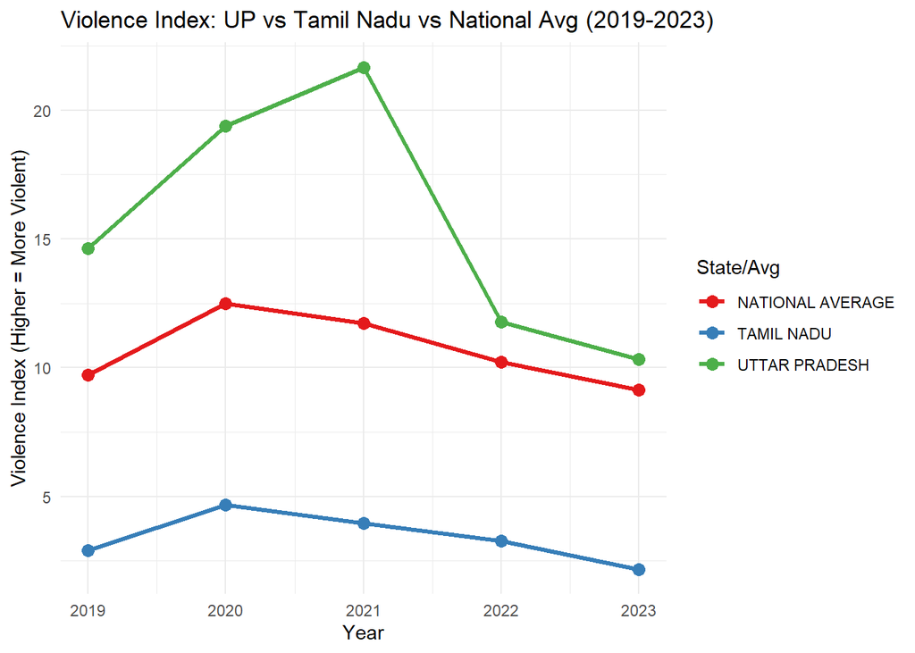

```r
index_data <- crime_data %>%
  mutate(
    Violence_Index = (Murder + `Attempt to commit Murder` + `Kidnapping & Abduction`) /
                     (Theft + Burglary + Robbery + 0.0001)
  )

national_avg <- crime_data %>%
  group_by(Year) %>%
  summarize(
    Violence_Index = sum(Murder + `Attempt to commit Murder` + `Kidnapping & Abduction`, na.rm = TRUE) /
                     (sum(Theft + Burglary + Robbery, na.rm = TRUE) + 0.0001)
  ) %>%
  mutate(State = "NATIONAL AVERAGE")

plot_data_q1 <- index_data %>%
  filter(toupper(trimws(State)) %in% c("UTTAR PRADESH", "TAMIL NADU")) %>%
  select(Year, State, Violence_Index) %>%
  bind_rows(national_avg)

ggplot(plot_data_q1, aes(x = Year, y = Violence_Index, color = State, group = State)) +
  geom_line(linewidth = 1.2) +
  geom_point(size = 3) +
  scale_color_brewer(palette = "Set1") +
  labs(title = "Violence Index: UP vs Tamil Nadu vs National Avg (2019-2023)",
       y = "Violence Index (Higher = More Violent)", x = "Year", color = "State/Avg") +
  theme_minimal()
```

## Sub-Question 2.2: Rank Mobility in Murder Convictions

**How many states changed their rank position in the Murder Conviction Count by more than 3 places between 2019 and 2023? Is the “Murder Capital” list rigid or fluid?**

### Statistical Methods Used

- Rank Mobility Index
- Tabular Comparison

### Step-by-Step Application

1. **Ranking 2019:** Ranked all states based on their total Murder convictions in 2019.
2. **Ranking 2023:** Ranked all states based on their total Murder convictions in 2023.
3. **Calculating the Shift:** Joined the datasets and calculated the absolute difference between the two ranks.
4. **Threshold Filtering:** Isolated states that experienced a rank shift of more than 3 positions.

### R Code

```r
rank_2019 <- crime_data %>%
  filter(Year == 2019) %>%
  mutate(Rank_2019 = min_rank(desc(Murder))) %>%
  select(State, Rank_2019)

rank_2023 <- crime_data %>%
  filter(Year == 2023) %>%
  mutate(Rank_2023 = min_rank(desc(Murder))) %>%
  select(State, Rank_2023)

rank_mobility <- inner_join(rank_2019, rank_2023, by = "State") %>%
  mutate(Rank_Change = Rank_2019 - Rank_2023) %>%
  filter(abs(Rank_Change) > 3) %>%
  arrange(desc(Rank_Change))

knitr::kable(rank_mobility, caption = "States with Rank Shifts > 3 Places (Murder Convictions)")
```

States with Rank Shifts > 3 Places (Murder Convictions)

| State | Rank_2019 | Rank_2023 | Rank_Change |
| --- | --- | --- | --- |
| GUJARAT | 13 | 6 | 7 |
| ARUNACHAL PRADESH | 33 | 27 | 6 |
| GOA | 25 | 29 | -4 |
| HARYANA | 6 | 10 | -4 |
| KARNATAKA | 10 | 14 | -4 |

### Interpretation

- **List Fluidity:** Gujarat experienced the most alarming shift, climbing 7 spots (from 13th to 6th) in murder convictions between 2019 and 2023. Arunachal Pradesh also saw a significant jump of 6 spots. These massive climbs indicate rapid regional destabilization or localized spikes in violence entering the courts.
- **Structural Inertia:** Conversely, states like Goa, Haryana, and Karnataka dropped 4 places down the rankings, indicating relative stabilization and improvement in their murder conviction rates compared to the rest of the country.
- **Conclusion:** Significant rank climbs serve as a red alert for policy makers, highlighting areas where new, non-traditional violence has begun entering the court system.

## Sub-Question 2.3: Assessing Lethality (Attempted vs. Actual Murder)

**Which states have an unusually low ratio of Attempt to Murder to Murder compared to their regional neighbors?**

### Statistical Methods Used

- Ratio Analysis
- Outlier Box Plot Visualization

### Step-by-Step Application

1. **Lethality Calculation:** Computed the average ratio of Attempt to Murder versus actual Murder convictions for each state.
2. **Outlier Detection:** Utilized the Interquartile Range (IQR) method to identify statistical lower outliers.
3. **Visualization:** Plotted the distribution on a box plot, explicitly labeling states that fall below the normal distribution threshold.

### R Code

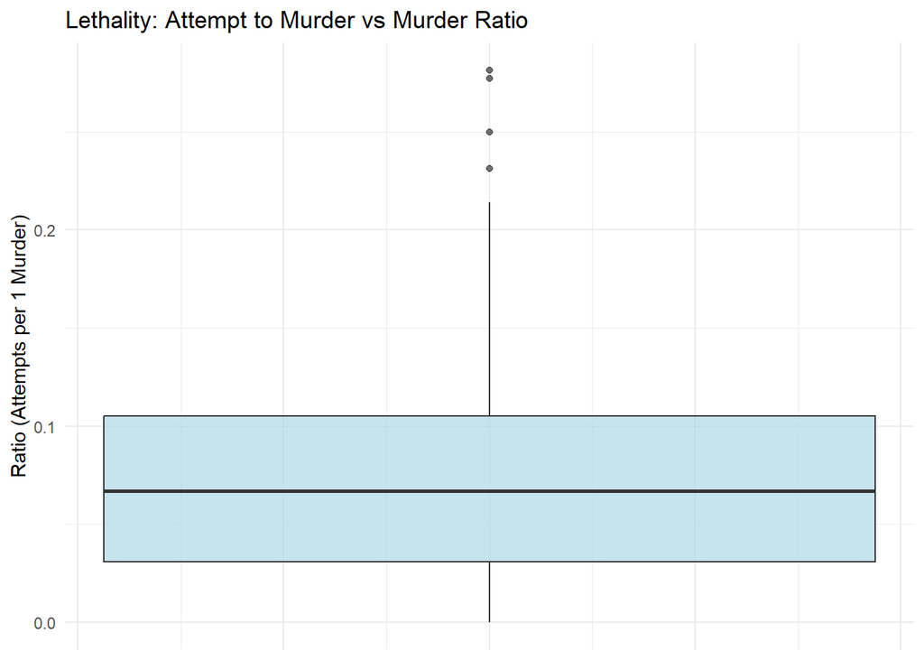

```r
lethality_data <- crime_data %>%
  group_by(State) %>%
  summarise(
    Avg_Murder = mean(Murder, na.rm = TRUE),
    Avg_Attempt = mean(`Attempt to commit Murder`, na.rm = TRUE)
  ) %>%
  mutate(Lethality_Ratio = Avg_Attempt / (Avg_Murder + 0.0001))

q1 <- quantile(lethality_data$Lethality_Ratio, 0.25, na.rm = TRUE)
iqr_val <- IQR(lethality_data$Lethality_Ratio, na.rm = TRUE)
lower_bound <- q1 - 1.5 * iqr_val

ggplot(lethality_data, aes(y = Lethality_Ratio)) +
  geom_boxplot(fill = "lightblue", alpha = 0.7) +
  geom_text(aes(x = 0, label = ifelse(Lethality_Ratio < lower_bound, State, "")),
            hjust = -0.5, color = "red", fontface = "bold") +
  labs(title = "Lethality: Attempt to Murder vs Murder Ratio",
       y = "Ratio (Attempts per 1 Murder)",
       x = NULL) +
  theme_minimal() +
  theme(axis.text.x = element_blank(), axis.ticks.x = element_blank())
```

### Interpretation

- **Statistical Floor Effect:** Because the median national ratio is clustered so closely to zero (~0.06), the standard IQR outlier threshold drops below zero. Therefore, standard outlier detection cannot flag lower bounds.
- **Total Lethality Focus:** However, states sitting at the absolute bottom of the whisker (at exactly 0.00) represent total lethality (zero attempts, only murders) and warrant specific forensic auditing.

## **Conclusion:** While a traditional statistical lower outlier cannot mathematically exist in this specific distribution, states clustered at absolute zero should still be treated as anomalies requiring immediate public health and policing interventions.

## Sub-Question 2.4: Volatility in Kidnapping and Abduction Convictions

**Group states into Low, Medium, and High tertiles based on their 5-year average Kidnapping & Abduction convictions. Which states in the Medium tertile show High Volatility (CV > 0.5)?**

### Statistical Methods Used

- Tertile Grouping (Rank-Based Classification)
- Coefficient of Variation (CV = SD / Mean)
- Threshold Filtering (CV > 0.5)

### Step-by-Step Application

1. **Tertile Assignment:** Calculated the 5-year mean for kidnapping convictions and split the states into three equal tertiles.
2. **Volatility Calculation:** Isolated the “Medium” tertile and computed the Standard Deviation and Coefficient of Variation (CV) for each state.
3. **Threshold Isolation:** Filtered out states with a CV greater than 0.5 (indicating standard deviation is half the mean).
4. **Visualization:** Plotted the 5-year trend for these highly volatile states to visualize the erratic nature of the convictions.

### R Code

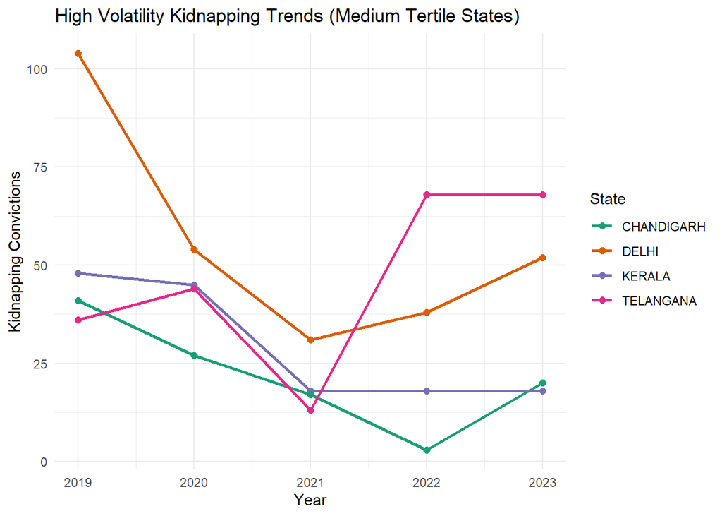

```r
kidnap_stats <- crime_data %>%
  group_by(State) %>%
  summarise(
    Mean_Kidnap = mean(`Kidnapping & Abduction`, na.rm = TRUE),
    SD_Kidnap = sd(`Kidnapping & Abduction`, na.rm = TRUE)
  ) %>%
  mutate(
    CV = SD_Kidnap / (Mean_Kidnap + 0.0001),
    Tertile = ntile(Mean_Kidnap, 3)
  )

volatile_medium_states <- kidnap_stats %>%
  filter(Tertile == 2, Mean_Kidnap > 10, CV > 0.5) %>%
  pull(State)

volatile_data <- crime_data %>%
  filter(State %in% volatile_medium_states)

if(length(volatile_medium_states) > 0) {
  ggplot(volatile_data, aes(x = Year, y = `Kidnapping & Abduction`, color = State)) +
    geom_line(linewidth = 1) +
    geom_point(size = 2) +
    scale_color_brewer(palette = "Dark2") +
    labs(title = "High Volatility Kidnapping Trends (Medium Tertile States)",
         y = "Kidnapping Convictions", x = "Year") +
    theme_minimal()
} else {
  cat("No states in the Medium Tertile with >10 avg exhibited High Volatility (CV > 0.5).\n")
}
```

## Sub-Question 2.5: Correlation Between Robbery and Burglary

**For each state, calculate the 5-year correlation (Pearson’s r) between Robbery and Burglary. Which states exhibit a strong negative correlation (r < -0.7)?**

### Statistical Methods Used

- Pearson Correlation Coefficient (r)
- Scatter Plot with Linear Trendline

### Step-by-Step Application

1. **Correlation Calculation:** Grouped data by state and computed Pearson’s r between Robbery and Burglary across the 5 paired annual observations.
2. **Threshold Filtering:** Identified states demonstrating a strong negative correlation (r < -0.7).
3. **Visualization:** Generated scatter plots for the flagged states, mapping Robbery on the X-axis and Burglary on the Y-axis, overlaid with a linear regression line.

### R Code

```r
cor_data <- crime_data %>%
  group_by(State) %>%
  summarise(
    Correlation = suppressWarnings(cor(Robbery, Burglary, use = "pairwise.complete.obs"))
  ) %>%
  filter(Correlation < -0.7)

negative_cor_states <- cor_data %>% pull(State)

plot_cor_data <- crime_data %>%
  filter(State %in% negative_cor_states)

if(length(negative_cor_states) > 0) {
  ggplot(plot_cor_data, aes(x = Robbery, y = Burglary)) +
    geom_point(size = 3, color = "darkred") +
    geom_smooth(method = "lm", se = FALSE, color = "steelblue", linewidth = 1) +
    facet_wrap(~State, scales = "free") +
    labs(title = "Robbery vs Burglary Substitution (r < -0.7)",
         x = "Robbery Convictions", y = "Burglary Convictions") +
    theme_minimal()
} else {
  cat("No states exhibited a strong negative correlation (r < -0.7).\n")
}
```

```
## No states exhibited a strong negative correlation (r < -0.7).
```

### Interpretation

- **Crime Substitution Effect:** The analysis returned no states exhibiting a strong negative correlation (r < -0.7). This disproves the direct substitution effect theory at the state level for this 5-year period; a decrease in burglary convictions does not systematically correlate with a direct pivot to street robbery.
- **Independent Criminal Markets:** Because the correlation is not strongly negative, it implies that robbery and burglary are largely driven by independent factors or different types of criminal networks, rather than individual offenders switching between the two based on opportunity.
- **Conclusion:** Police departments cannot rely on the assumption that reducing residential burglary will automatically increase street robbery. Interventions and specialized task forces for these two crimes should be developed as separate, targeted strategies.